# Manuscript Report: Low N Sedimentary Site 80_BO

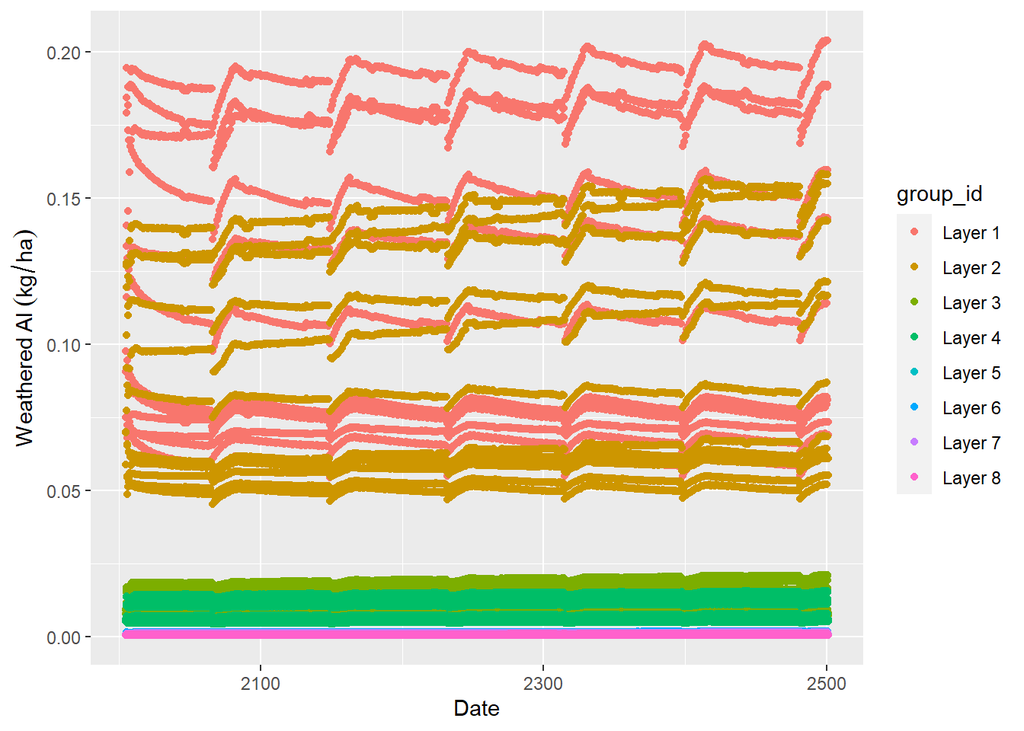

Aluminum Weathering (All Layer)

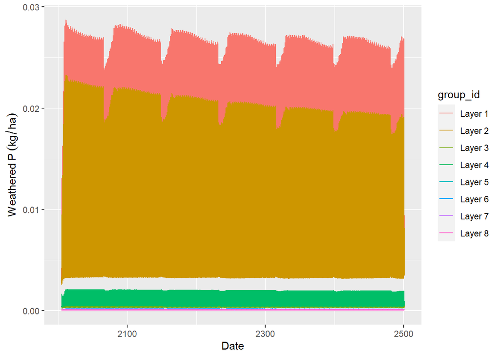

Phosphate Weathering (All Layer)

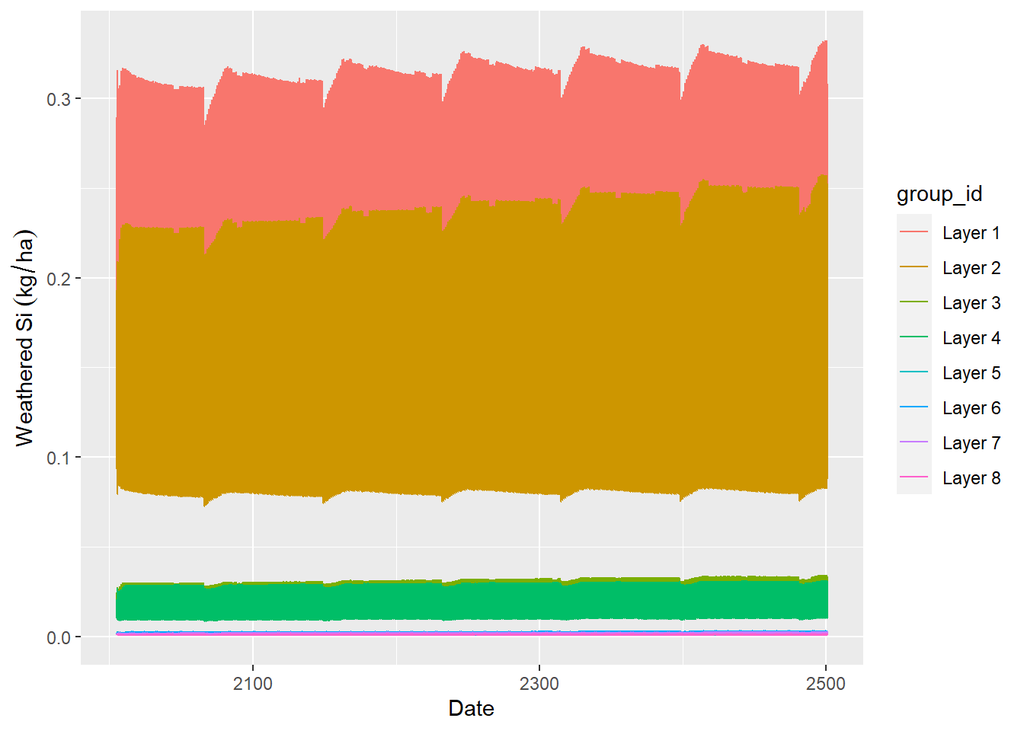

Silica Weathering (All Layer)

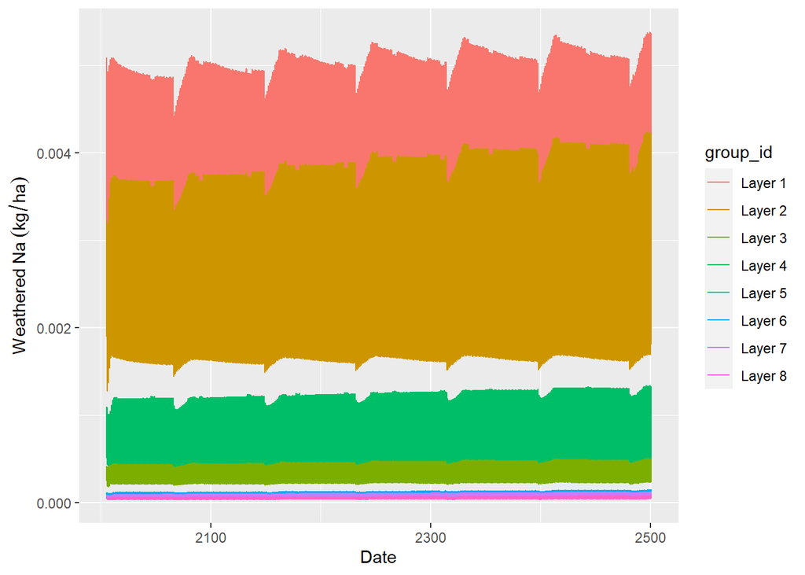

Sodium Weathering (All Layer)

### Litter Pool Results

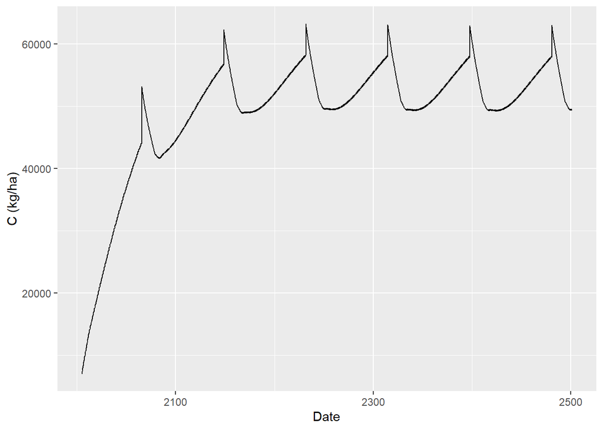

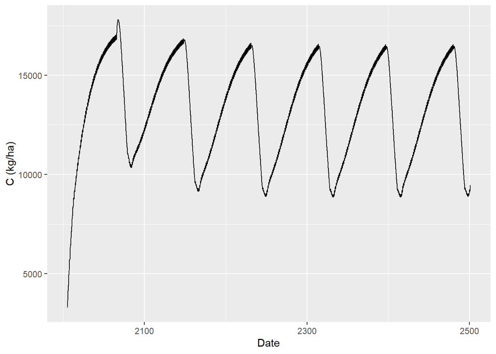

Forest Floor (O-Layer) Carbon Content Over Simulation Period

Looking at a range of soil carbon studies in Douglas-fir forests of the Pacific Northwest, forest floor (defined as non-mineral OM) C content goes from a lower bound of 3,700 kg C/ha in a 9-yr old stand[@cromackSoilCarbonNutrients1999] to 8200 kg C/ha in an average 38 year old stand [edmondsRelationshipsSoilOrganic1994]. These stands were notably N rich compared to the site simulated for the low N site, the soil C should be lower in the simulations as there is about half as much soil N in the low N simulated site as in the sites described in [edmondsRelationshipsSoilOrganic1994]. The high N site has about 21,000 kg N/ha at 1m depth, so it should be modeled to be at the higher end of organic and litter C buildup.

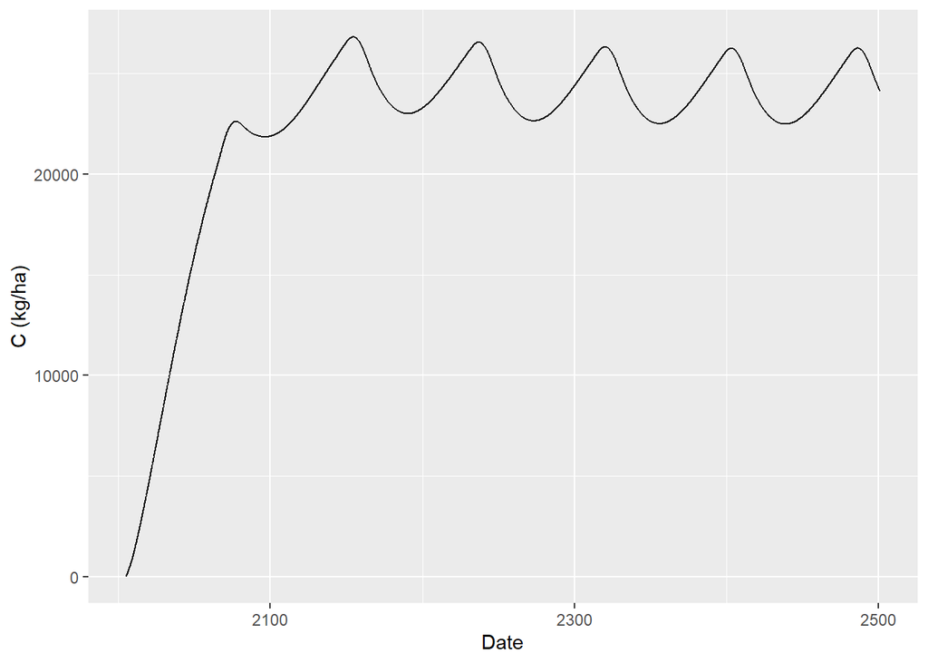

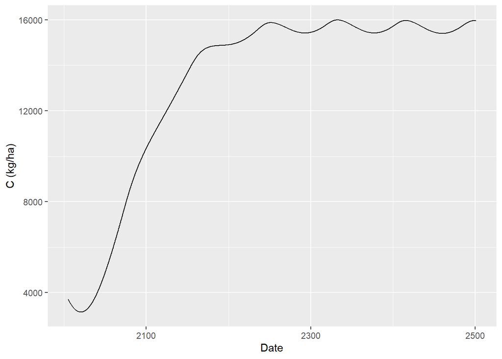

Forest Floor (O-Layer) Carbon Content Over Simulation Period

Note that the fine litter pool (the stage between humus and fresh/coarse litter) is growing in this model. This might deviate from observed behavior.

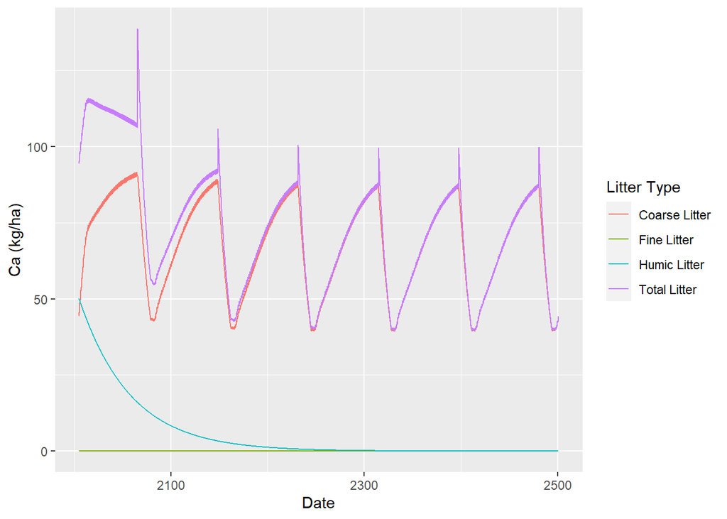

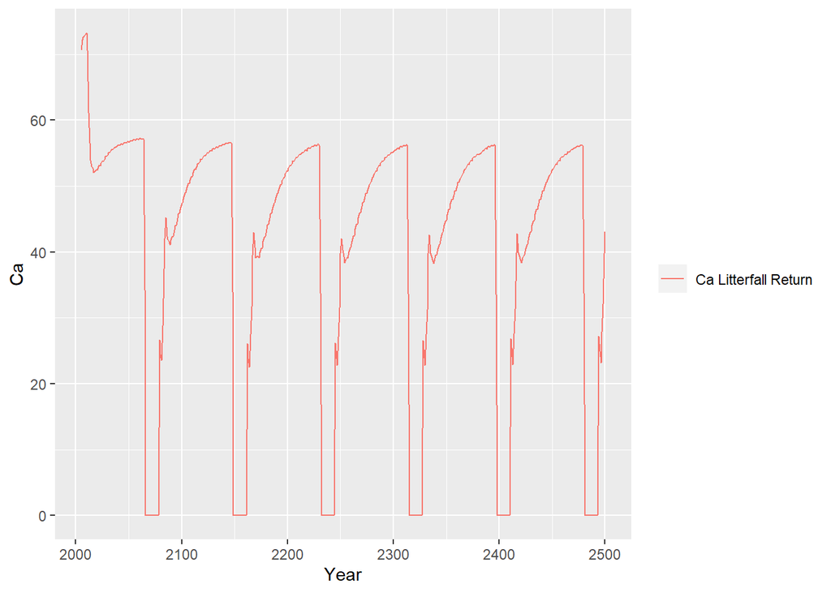

Forest Floor/O-horizon Ca content over time (a). and net annual Ca return in litterfall (b).